# Análisis de correlación y análisis de regresión

En el control de calidad, es importante investigar la relación entre dos variables, como los factores y las características.

Para ello, se utilizan el análisis de correlación, que examina la relación entre variables, y el análisis de regresión, que explica los cambios en una variable objetivo en función de otra variable.

- Dominar la explicación del significado del análisis de correlación y ser capaz de realizar una prueba de hipótesis de no correlación.
- Dominar la estimación en regresión lineal simple.
- Dominar el análisis de varianza (ANOVA) en regresión lineal simple.
- Dominar el análisis de residuos en regresión.

[Audio_1](https://drive.google.com/file/d/1FBt7LhjpTgEiyJyEJ-yvNRMaO5lDi-47/view?usp=drive_link)

```python
import os

try:
  os.chdir('../Python/QCKentei2')
except:
  pass

path = os.getcwd()
```

```python
import pandas as pd
import numpy as np
import matplotlib.pyplot as plt
from scipy import stats
import seaborn as sns
from PIL import Image
import statsmodels.formula.api as smf
from statsmodels.stats.anova import anova_lm

import statsmodels.api as sm
from statsmodels.formula.api import ols

import gspread
from google.oauth2.service_account import Credentials
```

## 08-01 Análisis de correlación

相関分析

### 1. El análisis de correlación es:

相関分析とは

Cuando las mediciones emparejadas de dos tipos, $ x $ e $ y $, muestran que la media poblacional de $ y $ cambia linealmente en respuesta a los cambios en $ x $, se dice que existe una **correlación** entre ambas. El método estadístico para determinar la presencia de esta correlación se denomina **análisis de correlación**. La existencia y fuerza de una relación correlacional pueden apreciarse aproximadamente mediante un diagrama de dispersión, pero para su determinación estadística se utiliza el **coeficiente de correlación r**.

- $ r = S_{xy} / \sqrt{S_{xx} S_{yy}}$
- El coeficiente de correlación $ r $ toma valores de -1 a +1. Cuanto más se acerca a -1, más fuerte es la correlación negativa. Cuanto más se acerca a +1, más fuerte es la correlación positiva. Además, cuanto nás se aproxima a 0, más débil es la correlación, llegando a ser **no correlacionado**.
  - Correlación positiva
  - Correlación negativa
  - Sin correlación / Correlación nula
- El coeficiente de correlación mide el grado en que $ x $ e $ y $ tienen una **relación lineal**. Si hay **valores atipicos** en el conjunto de datos o si la relación es **curvilínea**, calcular el coeficiente de correlación carece de sentido.
- El coeficiente de correlación tiene sentido cuando tanto $ x $ como $ y $ siguen una **distribución normal**.

[Audio_2](https://drive.google.com/file/d/1Fn_Fx2mM4jbVafBGSDo3KDCLDeawNCK1/view?usp=drive_link)

### 2. Cálculo del coeficiente de correlación y prueba de no correlación

相関係数の計算と無相関の検定

[Audio_3](https://drive.google.com/file/d/16Y2P4crEpogDlsZPh1hVGNoqHnTghrfO/view?usp=drive_link)

## 8.1

特殊金属材料についてQ成分含有量 x(ppm) と伸び y(%) との関係を調査し、表８．２を得た。ｘとｙの関係について相関分析をおこなえ。

Se investigó la relación entre el contenido del componente Q, x (ppm), y la elongación, y(%), en un material metálico especial, y se obtuvo la Tabla 8.2. Realice un análisis de correlación sobre la relación entre x e y.

```python
SERVICE_ACCOUNT_FILE = "my-project-vscode-452201-249bdb033f8c.json"  # JSONファイルのパス
SCOPES = ["https://www.googleapis.com/auth/spreadsheets"]

credentials = Credentials.from_service_account_file(SERVICE_ACCOUNT_FILE, scopes=SCOPES)
client = gspread.authorize(credentials)

# スプレッドシートを開く（URLまたはスプレッドシートIDを使用）
SPREADSHEET_ID = "1Ma7ehT4TAnkUwJjspP-C3mwJA1hYmbJr8B9GJSFI0lU"
sheet = client.open_by_key(SPREADSHEET_ID).worksheet("Sheet22") # 最初のシートを取得

# データを取得
list_of_lists = sheet.get_all_records()
df = pd.DataFrame(list_of_lists)

df = df.set_index("No")
df = df.astype(float)

df.to_excel("./Data2/Data_8_3.xlsx",index=True)

print("Tabla 8.3")
df
```

```
Tabla 8.3
```

| No | x | y |
| --- | --- | --- |
| 1 | 45.0 | 3.0 |
| 2 | 68.0 | 16.0 |
| 3 | 71.0 | 29.0 |
| 4 | 76.0 | 22.0 |
| 5 | 60.0 | 11.0 |
| 6 | 64.0 | 15.0 |
| 7 | 67.0 | 18.0 |
| 8 | 45.0 | 5.0 |
| 9 | 50.0 | 7.0 |
| 10 | 52.0 | 8.0 |
| 11 | 45.0 | 3.0 |
| 12 | 53.0 | 9.0 |
| 13 | 59.0 | 22.0 |
| 14 | 48.0 | 5.0 |
| 15 | 59.0 | 14.0 |
| 16 | 47.0 | 5.0 |
| 17 | 45.0 | 9.0 |
| 18 | 66.0 | 22.0 |
| 19 | 54.0 | 9.0 |
| 20 | 55.0 | 15.0 |
| 21 | 63.0 | 21.0 |
| 22 | 80.0 | 29.0 |
| 23 | 80.0 | 34.0 |
| 24 | 52.0 | 16.0 |
| 25 | 60.0 | 6.0 |
| 26 | 43.0 | 5.0 |
| 27 | 55.0 | 8.0 |
| 28 | 58.0 | 9.0 |
| 29 | 54.0 | 12.0 |
| 30 | 64.0 | 16.0 |

Gráfico 8.3 Diagrama de dispersión del contenido del componente Q (x) y la elongación (y)

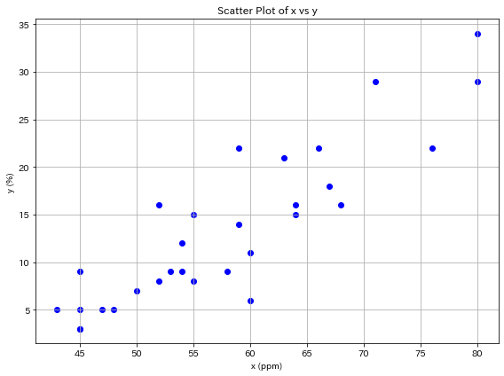

```python
from scipy import stats

# Scatter Plot
plt.figure(figsize=(8, 6))
plt.scatter(df['x'], df['y'], color='blue')
plt.title('Scatter Plot of x vs y')
plt.xlabel('x (ppm)')
plt.ylabel('y (%)')
plt.grid(True)
plt.tight_layout()
plt.show()
```

#### (1) Cálculo del coeficiente de correalción

相関係数の計算

- $ r = S_{xy} / \sqrt{S_{xx} S_{yy} } = 0.885 $

```python
# Cálculo del coeficiente de correlación
r, p_value = stats.pearsonr(df['x'], df['y'])

print(f"Coeficiente de correlación de Pearson (r): {r:.3f}")
print(f"p-value: {p_value:.3f}")
```

```
Coeficiente de correlación de Pearson (r): 0.885
p-value: 0.000
```

Paso 1: Creacón de la tabla de cálculo

```python
df2 = pd.read_excel("./Data2/Data_8_3.xlsx")

df2 = df2.set_index(df2.columns[0])
df2['x^2'] = df2['x']**2
df2['y^2'] = df2['y']**2
df2['xy'] = df2['x']*df['y']
total_row = df2.sum(axis=0)
total_row.name = 'Total'
df2 = pd.concat([df2, pd.DataFrame([total_row])])
df2
```

|  | x | y | x^2 | y^2 | xy |
| --- | --- | --- | --- | --- | --- |
| 1 | 45.0 | 3.0 | 2025.0 | 9.0 | 135.0 |
| 2 | 68.0 | 16.0 | 4624.0 | 256.0 | 1088.0 |
| 3 | 71.0 | 29.0 | 5041.0 | 841.0 | 2059.0 |
| 4 | 76.0 | 22.0 | 5776.0 | 484.0 | 1672.0 |
| 5 | 60.0 | 11.0 | 3600.0 | 121.0 | 660.0 |
| 6 | 64.0 | 15.0 | 4096.0 | 225.0 | 960.0 |
| 7 | 67.0 | 18.0 | 4489.0 | 324.0 | 1206.0 |
| 8 | 45.0 | 5.0 | 2025.0 | 25.0 | 225.0 |
| 9 | 50.0 | 7.0 | 2500.0 | 49.0 | 350.0 |
| 10 | 52.0 | 8.0 | 2704.0 | 64.0 | 416.0 |
| 11 | 45.0 | 3.0 | 2025.0 | 9.0 | 135.0 |
| 12 | 53.0 | 9.0 | 2809.0 | 81.0 | 477.0 |
| 13 | 59.0 | 22.0 | 3481.0 | 484.0 | 1298.0 |
| 14 | 48.0 | 5.0 | 2304.0 | 25.0 | 240.0 |
| 15 | 59.0 | 14.0 | 3481.0 | 196.0 | 826.0 |
| 16 | 47.0 | 5.0 | 2209.0 | 25.0 | 235.0 |
| 17 | 45.0 | 9.0 | 2025.0 | 81.0 | 405.0 |
| 18 | 66.0 | 22.0 | 4356.0 | 484.0 | 1452.0 |
| 19 | 54.0 | 9.0 | 2916.0 | 81.0 | 486.0 |
| 20 | 55.0 | 15.0 | 3025.0 | 225.0 | 825.0 |
| 21 | 63.0 | 21.0 | 3969.0 | 441.0 | 1323.0 |
| 22 | 80.0 | 29.0 | 6400.0 | 841.0 | 2320.0 |
| 23 | 80.0 | 34.0 | 6400.0 | 1156.0 | 2720.0 |
| 24 | 52.0 | 16.0 | 2704.0 | 256.0 | 832.0 |
| 25 | 60.0 | 6.0 | 3600.0 | 36.0 | 360.0 |
| 26 | 43.0 | 5.0 | 1849.0 | 25.0 | 215.0 |
| 27 | 55.0 | 8.0 | 3025.0 | 64.0 | 440.0 |
| 28 | 58.0 | 9.0 | 3364.0 | 81.0 | 522.0 |
| 29 | 54.0 | 12.0 | 2916.0 | 144.0 | 648.0 |
| 30 | 64.0 | 16.0 | 4096.0 | 256.0 | 1024.0 |
| Total | 1738.0 | 403.0 | 103834.0 | 7389.0 | 25554.0 |

Paso 2: Cálculo de la suma de cuadrados y la suma de productos

$ Sxx = \sum (x_i - \bar{x})^2 $

$ Syy = \sum (y_i - \bar{y})^2 $

$ Sxy = \sum (x_i - \bar{x})(y_i - \bar{y}) $

```python
def compute_Sxx_Syy_Sxy(df, x_col='x', y_col='y'):
    df_trimmed = df.iloc[:-1]
    centered = df_trimmed[[x_col, y_col]] - df_trimmed[[x_col, y_col]].mean()
    Sxx = (centered[x_col] ** 2).sum()
    Syy = (centered[y_col] ** 2).sum()
    Sxy = (centered[x_col] * centered[y_col]).sum()
    return Sxx, Syy, Sxy

Sxx, Syy, Sxy = compute_Sxx_Syy_Sxy(df2)

print(f'Sxx: {Sxx:.1f} Syy: {Syy:.1f} Sxy: {Sxy:.1f}')
```

```
Sxx: 3145.9 Syy: 1975.4 Sxy: 2206.9
```

Paso 3: Cálculo del coeficiente de correlación

$ r = Sxy / \sqrt{Sxx Syy} $

```python
r = Sxy / (Sxx**0.5 * Syy**0.5)

print(f'r: {r:.3f}')
```

```
r: 0.885
```

#### (2) Prueba de hipótesis para el coeficiente de correlación poblacional (Prueba de no correlación)

母相関係数の検定（無相関の検定）

Paso 1: EStablecimiento del objetivo de la prueba

Se realiza una prueba bilateral para determinar si existe una relación de correlación entre $ x $ e $ y $

Paso 2: Establecimiento de la hipótesis nula H0 y la hipótesis alternativa H1.

- $ H_0 : \rho = 0 $
- $ H_1 : \rho \neq 0 $

Paso 3: Selección del estadístico de prueba.

- $ t_0 = r \sqrt{n-2} / \sqrt{1-r^2}$

Paso 4: Establecimiento del nivel de significancia.

- $ \alpha = 0.05 $

Paso 5: Determinación de la región de rechazo.

- $ R : | t_0 | \geq t(\phi, \alpha) = t(n-2, \alpha) = t(28, 0.05) = 2.048 $

Paso 6: Cálculo del estadístico de prueba.

Paso 7: Decisión sobre el resultado de la prueba.

- $ | t_0 | = 10.06 > t(28, 0.05) = 2.048 $

Paso 8: Conclusión.

- La hipótesis nula H0 fue rechazada y la hipótesis alternativa H1 fue aceptada. Con un nivel de significancia del 5%, se puede decir que existe una relación de correlación entre x e y.

[Audio_4](https://drive.google.com/file/d/1gi0AphNrcAfbmbzAVys-yWcbAxdTeF0J/view?usp=drive_link)

```python
from scipy.stats import t

n = len(df)
df_t = n - 2

# Paso 4:  Establecimiento del nivel de significancia
alpha = 0.05

# Paso 5: Región de rechazo
R = t.ppf(1 - alpha/2, df_t)

# Paso 6: Estadístico de prueba
t_0 = r * np.sqrt(n - 2) / np.sqrt(1 - r**2)

print(f"Región de rechazo R : |t0| = {t_0:.2f} > {R:.3f}")
```

```
Región de rechazo R : |t0| = 10.07 > 2.048
```

### 3. Autocorrelación de series

系列相関

Cuando se investiga la relación de correlación entre dos variables, y la distribución de cada variable se desvía de la normalidad c existen valores atípicos cuyo no puede ignorarse, a veces se realizan las **pruebas de correlación de grandes olas y de pequeñas olas**. Ambas se llevan a cabo mediante una prueba de signos.

#### (1) Prueba de los signos

符号検定

#### (2) Prueba de correlación para ondas grandes

大波の相関の検定

#### (3) Prueba de correlación para ondas pequeñas

小波の相関の検定

[Audio_5](https://drive.google.com/file/d/1Q5BN3-T2SlNXQrkFH-pD9wquqBciNLDw/view?usp=drive_link)

## 08-02 Análisis de regresión

単回帰分析

### 1. Qué es una ecuación de regresión

回帰分析とは

Mientras que el análisis de correlación es una técnica para analizar la relación entre dos variables, el análisis de regresión tiene como objetivo estimar el cambio en una variable objetivo basándose en el valor de la otra variable.

Se llama **análisis de regresión simple** cuando hay una sola variable explicativa, y **análisis de regresión múltiple** cuando hay dos o más variables explicativas.

Se puede decir que el análisis de regresión es un método para encontrar la ecuación de relación (**ecuación de regresión**) entre una variable objetivo (**variable dependiente**) y una variable explicativa (**variable independiente**).

La **ecuación de regresión** se determina al encontrar la **pendiente** y la **intersección** de la recta de manera que la suma de los cuadrados de las diferencia entre los valores del eje vertical de los puntos en el diagrama de dispersión (valores observados) y los valores del eje vertical en la recta de regresión correspondientes a los valores del eje horizontal (valores observados ) sea la mínima posible (para todos los punto del diagram de dispersión). Este método se conoce como **método de mínimos cuadrados**.

### 2. Ecuación de regresión

回帰式

El análisis de regresión tiene como objetivo realizar predicciones y control sobre una **variable objetivo** utilizando las **variables explicativas**.

- $ y_i = a + b x_i + \epsilon_i $
- Variable dependiente / Variable de respuesta / Variable objetivo
- Variable independiente / Variable predictora / Regresor

### 3. Método de los mínimos cuadrados y Estimación de regresión lineal simple

最小二乗法と単回帰式の推定

El análisis de regresión simple es un método para encontrar a y b de manera que la suma de cuadrados de los residuos (SEC) sea mínima.

- $ b = S_{xy} / S_{xx} $
- $ \bar{y} -b \bar{x} = \bar{y} - (S_{xy} / S_{xx}) \bar{x} $

[Audio_6](https://drive.google.com/file/d/1Skj9o2D8UXeQmzh-YR4Ap_gvYhappOBa/view?usp=drive_link)

## 8.2

表８．２のデータから回帰式を求めよ。

Obtenga la ecuación de regresión a partir de los datos de la Tabla 8.2

Paso 1: Cálculo de las medias de x e y

$ \bar{x} = \frac{1}{n} \sum x_i $

$ \bar{y} = \frac{1}{n} \sum y_i $

```python
xbar = df2.iloc[:-1]['x'].mean()
ybar = df2.iloc[:-1]['y'].mean()

print(f'xbar: {xbar:.2f}  ybar: {ybar:.2f}')
```

```
xbar: 57.93  ybar: 13.43
```

Paso 2: Cálculo del coeficiente de regresión b

$ b = Sxy / Sxx $

```python
Sxx, Syy, Sxy = compute_Sxx_Syy_Sxy(df2)

b = Sxy/Sxx
print(f'b: {b:.4f}')
```

```
b: 0.7015
```

Paso 3: Cálculo de intercepto a

$ a = \bar{y} - b \bar{x} $

```python
a = ybar - b*xbar
print(f'a : {a:.2f}')
```

```
a : -27.21
```

Paso 4: Determinación de la ecuación de regresión

$ y = a + bx = -27.21 + 0.7015x $

Paso 5: Dibujar la ecuación de regresión en el diagrama de dispersión

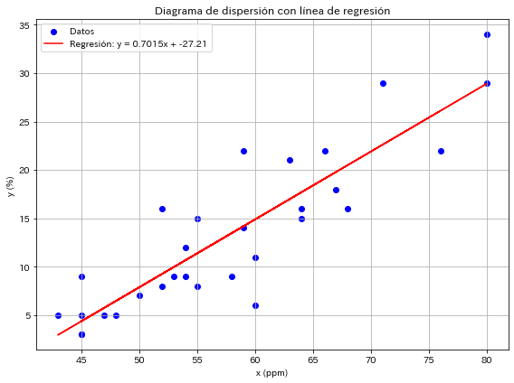

```python
x = np.array(df2.iloc[:-1]['x'])
y = np.array(df2.iloc[:-1]['y'])

# Regrasión lineal
slope, intercept, r_value, p_value, std_err = stats.linregress(x, y)

# Recta de regresión
regression_line = slope * x + intercept

#
plt.figure(figsize=(8, 6))
plt.scatter(x, y, color='blue', label='Datos')
plt.plot(x, regression_line, color='red', label=f'Regresión: y = {slope:.4f}x + {intercept:.2f}')
plt.title('Diagrama de dispersión con línea de regresión')
plt.xlabel('x (ppm)')
plt.ylabel('y (%)')
plt.legend()
plt.grid(True)
plt.tight_layout()
plt.show()
```

### 4. Descomposición de la suma de cuadrados y análisis de varianza

平方和の分解と分散分析

Se puede utilizar el análisis de varianza (ANOVA) para analizar si la regresión es significativa.

La suma total de cuadrados se puede descomponer en la suma de cuadrados de la regresión y la suma de cuadrados residual.

- $ S_{yy} = S_E + S_{R} $

[Audio_7](https://drive.google.com/file/d/1Ye5-yWBWZe0i0ORkq_ZGiycXEP03komi/view?usp=drive_link)

## 8.3

表８．２のデータから分散分析を行い、さらに寄与率を求めよ。

Realice un análisis de varianza utilizando los datos de la tabla 8.2 y calcule también la tasa de contribución.

Paso 1: Cálculo de la suma de cuadrados

- $ S_T = S_{yy} = 1975.4 $
- $ S_R = S_{xy^2} / S_{xx} = 1548.2 $
- $ S_E = S_T - S_R = 427.2$

Paso 2: Cálculo de los grados de libertad

- $ \phi_T = n - 1 = 29 $
- $ \phi_R = 1 $
- $ \phi_E = \phi_T - \phi_R = 28 $

```python
Sxx, Syy, Sxy = compute_Sxx_Syy_Sxy(df2)

# Paso 1:
ST = Syy
SR = Sxy**2/Sxx
SE = ST - SR

print(f'Suma Total de Cuadrados STC: {ST:.1f}')
print(f'Suma de Cuadrados de la Regresión SCR: {SR:.1f}')
print(f'Suma de Cuadrados de los Residuous SCE: {SE:.1f}')

# Paso 2:
n = len(df2.iloc[:-1])

dfT = n - 1
dfR = 1
dfE = dfT - dfR

print(f'\nGrados de libertad de la Suma Total de Cuadrados: {dfT}')
print(f'Grados de libertad de la Suma de Cuadrados de la Regresión {dfR}')
print(f'Grados de libertad de la Suma de Cuadrados de los Residuos: {dfE}')
```

[output not shown]

Paso 3: Creación de la tabla ANOVA / Elaboración de la tabla de análisis de varianza

- ANOVA

Paso 4: Determinación / Decisión / Evaluación / Juicio

- $ R : F_0 = 101.45 \geq F(\phi_R, \phi_E:\alpha) = 4.20$
- Con un nivel de significado del 5%, la regresión es significativa.

Paso 5: Cálculo del coeficiente de determinación / Cálculo de la proporción de varianza explicada

```python
# Paso 3: 回帰分析モデルのフィット
model = smf.ols('y ~ x', data=df).fit()
# 分散分析の結果を表示
anova_results = anova_lm(model)
print("ANOVA:")
print(anova_results)

# Paso 5: 寄与率の計算
total_variance = np.var(df['y'], ddof=1)
explained_variance = model.rsquared * total_variance
residual_variance = (1 - model.rsquared) * total_variance
print(f'\nExplained Variance (寄与率): {explained_variance:.4f}')
print(f'Residual Variance (残差の分散): {residual_variance:.4f}')
print(f"\nCoeficiente de determinación R² = {model.rsquared:.4f}")
```

```
ANOVA:
            df       sum_sq      mean_sq           F        PR(>F)
x          1.0  1548.145869  1548.145869  101.465295  8.195103e-11
Residual  28.0   427.220798    15.257886         NaN           NaN

Explained Variance (寄与率): 53.3843
Residual Variance (残差の分散): 14.7318

Coeficiente de determinación R² = 0.7837
```

Paso 6: Consideración de los residuos / Análisis de los residuos / Examen de los residuos

Cuando el coeficiente de determinación (o $ R^2 $) es bajo, significa que los residuos, que son las diferencias de los puntos de datos a la línea de regresión, son grandes. En el análisis de regresión, es crucial examinar detenidamente el diagrama de dispersión con la línea de regresión, así como realizar una análisis de los residuos como se detalla a continuación.

Si hay valores atípicos en el histograma de residuos, se debe investigar esos datos. Si se observan anomalías en el gráfico de series de tiempo, se podría considerar la influencia del orden de medición. Si se aprecia una relación curvilínea en el diagrama de dispersión de los residuos contra la variable explicativa, es necesario considerar la inclusión de un término cuadrático de la variable explicativa.

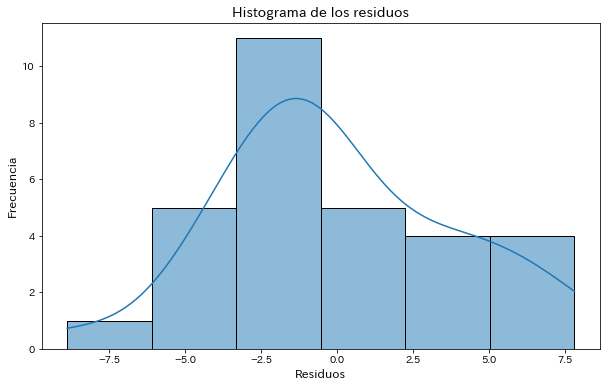

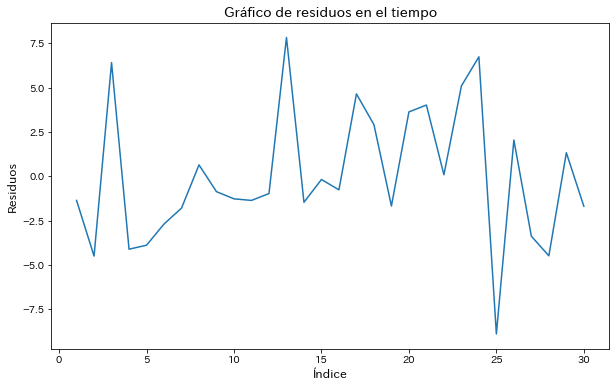

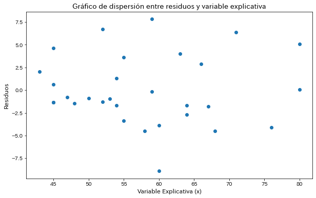

```python
# Cálculo de los residuos
residuals = model.resid

# Histograma de los residuos
plt.figure(figsize=(10, 6))
sns.histplot(residuals, kde=True)
plt.title('Histograma de los residuos', fontsize=14)
plt.xlabel('Residuos', fontsize=12)
plt.ylabel('Frecuencia', fontsize=12)
plt.show()

# Gráfico de los residuos en función del tiempo
plt.figure(figsize=(10, 6))
plt.plot(residuals)
plt.title('Gráfico de residuos en el tiempo', fontsize=14)
plt.xlabel('Índice', fontsize=12)
plt.ylabel('Residuos', fontsize=12)
plt.show()

# Diagrama de dispersión de los residuos frente a la variable explicativa
plt.figure(figsize=(10, 6))
plt.scatter(df['x'], residuals)
plt.title('Gráfico de dispersión entre residuos y variable explicativa', fontsize=14)
plt.xlabel('Variable Explicativa (x)', fontsize=12)
plt.ylabel('Residuos', fontsize=12)
plt.show()
```

## Por favor, responda a las preguntas del examen de práctica a través del siguiente enlace.

[Simulacro de examen](https://forms.gle/SmhuxJFtxMzP8XX5A)

## 15.3

製品Pの製造工程において、圧縮強度と引っ張り強さは重要な管理項目となっている。最近の生産量より、ランダムに n= 52 のサンプルを抜き取り、それぞれのサンプルから圧縮強度 (x) と引っ張り強さ (y) を測定したところ、以下の統計量が得られた。圧縮強度と引っ張り強さの間に、相関関係が存在するかどうか、有意水準５％で検定せよ。

En el proceso de fabricación del producto P, la resistencia a la compresión y la resistencia a la tracción son elementos de control importantes. Basándonos en la producción reciente, se tomó una muestra aleatoria de n = 52 unidades, y de cada muestra se midió la resistencia a la compresión (x) y la resistencia a la tracción (y), obteniéndose las siguientes estadísticas. Determine si existe una correlación significativa entre la resistencia a la compresión y la resistencia a la tracción, con un nivel de significancia del 5%.

n = 52,

$ \sum x = 281.00 \qquad \sum x^2 = 1668.00 \qquad \bar{x} = 5.404 \qquad S_{xx} = 149.519 $

$ \sum y = 4160.00 \qquad \sum y^2 = 332864.00 \qquad \bar{y}= 80.00 \qquad S_{yy} = 63.923 $

$ \sum xy = 22548.00 $

$ \alpha = 0.05 $

```python
import numpy as np
from scipy import stats

# Datos proporcionados
n = 52
sum_x = 281.00
sum_xx = 1668.00
mean_x = 5.404
S_xx = 149.519
sum_y = 4160.00
sum_yy = 332864.00
mean_y = 80.00
S_yy = 63.923
sum_xy = 22548.00
```

Paso 1: Establecimiento de la hipótesis

$ H_0 : \rho = 0 $

$ H_1 : \rho \neq 0 $

Paso 2: Establecimiento del nivel de significancia

$ \alpha = 0.05 $

```python
alpha = 0.05
```

Paso 3: Establecimiento de la región de rechazo

$ R: |r| \geq r(\phi,\alpha) = r(50,0.05) = 0.2732 $

```python
# Cálculo de los grados de libertad y valor p
df = n - 2
alpha = 1 - alpha / 2  # Convert two-tailed P value to one-tailed alpha
t_critical = stats.t.ppf(alpha, df)
r_critical = t_critical / np.sqrt(df + t_critical**2)

print(f"Grados de libertad df: {df}")
print(f"Región de rechazo R: {r_critical:.4f}")
```

```
Grados de libertad df: 50
Región de rechazo R: 0.2732
```

Paso 4: Cálculo del estadístico de prueba

$ S_{xx} = 149.519 \qquad S_{yy} = 63.923 $

$ S_{xy} = \sum xy - \frac{1}{n} (\sum x \times \sum y) = 68.000 $

$ r = S_{xy} / \sqrt{S_{xx} S_{yy}} = 0.696 $

```python
# Cálculo del coeficiente de correlación r
S_xy = sum_xy - (sum_x * sum_y)/n
r = S_xy / np.sqrt(S_xx * S_yy)

print(f"Sxy S_xy: {S_xy:.3f}")
print(f"Coeficiente de correlación r: {r:.3f}")
```

```
Sxy S_xy: 68.000
Coeficiente de correlación r: 0.696
```

Paso 5: Prueba de hipótesis

```python
# 有意水準5%での判断
if r > r_critical:
    print("Se rechaza la hipótesis nula. La correlación es significativa.")
else:
    print("No se puede rechazar la hipótesis nula. La correlación no es significativa.")
```

```
Se rechaza la hipótesis nula. La correlación es significativa.
```

```python
# 検算
mean_x_calc = sum_x / n
mean_y_calc = sum_y / n

S_xx_calc = sum_xx - n * mean_x_calc**2
S_yy_calc = sum_yy - n * mean_y_calc**2
S_xy_calc = sum_xy - n * mean_x_calc * mean_y_calc

# 与えられた S_yy から sum_yy を逆算
# S_yy = sum_yy - n * mean_y^2 より
sum_yy_calc = S_yy + n * mean_y_calc**2

# 相関係数 r の計算
r = S_xy_calc / np.sqrt(S_xx_calc * S_yy)

# t値の計算（相関係数の検定）
df = n - 2
t_stat = r * np.sqrt(df / (1 - r**2))

# 信頼区間のための標準誤差とt分布による臨界値
import scipy.stats as stats

alpha = 0.05
t_crit = stats.t.ppf(1 - alpha / 2, df)
se_r = np.sqrt((1 - r**2) / df)
ci_low = r - t_crit * se_r
ci_high = r + t_crit * se_r

sum_yy_calc, r, t_stat, (ci_low, ci_high)
```

```
(332863.923,
 np.float64(0.695555535492561),
 np.float64(6.845525032176445),
 (np.float64(0.491471202703038), np.float64(0.899639868282084)))
```

```
相関係数 r = 0.640
相関係数 r = 0.640
p値 = 3.160846772456941e-07
```

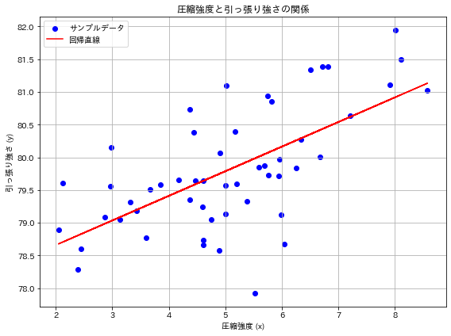

```python
import matplotlib.pyplot as plt
import japanize_matplotlib
from scipy.stats import pearsonr

# 仮のサンプルデータ生成（相関係数 ≈ 0.696 を持つように）
np.random.seed(42)
x = np.random.normal(loc=mean_x_calc, scale=np.sqrt(S_xx_calc / (n - 1)), size=n)
# y は x と相関を持たせて生成（回帰係数などは仮定）
slope = r * (np.sqrt(S_yy / S_xx_calc))
intercept = mean_y_calc - slope * mean_x_calc
y = intercept + slope * x + np.random.normal(scale=np.sqrt(S_yy * (1 - r**2) / (n - 2)), size=n)

# 相関係数を計算
r = np.corrcoef(x, y)[0, 1]
print(f"相関係数 r = {r:.3f}")

# 相関係数とp値を取得
r, p_value = pearsonr(x, y)
print(f"相関係数 r = {r:.3f}")
print("p値 =", p_value)

# 回帰直線のパラメータ
m, b = np.polyfit(x, y, 1)

# グラフの描画
plt.figure(figsize=(8, 6))
plt.scatter(x, y, color="blue", label="サンプルデータ")
plt.plot(x, m * x + b, color="red", label="回帰直線")
plt.title("圧縮強度と引っ張り強さの関係")
plt.xlabel("圧縮強度 (x)")
plt.ylabel("引っ張り強さ (y)")
plt.grid(True)
plt.legend()
plt.tight_layout()
plt.show()
```

## 15.4

製品HKの製造工程において、水分含有量と不純物量は重要な管理項目となっている。最近の生産品より、ランダムに $ n = 32 $ のサンプルを抜き取り、それぞれのサンプルから水分含有量 (x) と不純物量 (y) を測定したところ、以下の統計量が得られた。

水分含有量 (x) と不純物量 (y) の間に直線関係が存在するか否か、回帰分析を行え。有意水準５％とする。またその時の直線式（母回帰式）を推定せよ。

En el proceso de fabricación del producto HK, el contenido de humedad y la cantidad de impurezas son elementos de control importantes. Recientemente, se extrajo una muestra aleatoria de $ n = 32 $ unidades de la producción y se midió el contenido de humedad (x) y la cantidad de impurezas (y) de cada muestra, obteniéndose los siguientes estadísticos. Realice un análisis de regresión para determinar si existe una relación lineal entre el contenido de humedad (x) y la cantidad de impurezas (y). Utilice un nivel de significancia del 5%. Además, estime la ecuación de la recta (ecuación de regresión poblacional) en ese caso.

n = 32,

$ \sum x = 164.00 \qquad \sum x^2 = 950.00 \qquad \bar{x} = 5.125 \qquad S_{xx} = 109.50 $

$ \sum xy = 746.00 \qquad S_{xy} = 90.00$

$ \alpha = 0.05 $

```python
import numpy as np
import scipy.stats as stats
import matplotlib.pyplot as plt
from scipy.stats import f_oneway
import statsmodels.formula.api as smf

# Estadístico de prueba dado
n = 32
sum_x = 164.0
sum_xx = 950.0
x_bar = 5.125
Sxx = 109.50
sum_y = 1280.0
sum_yy = 51264.0
y_bar = 40.0
Syy = 97.00
sum_xy = 746.0
Sxy = 90.00
```

Paso 1: Estructura de los datos

$ y = \beta_0 + \beta_1 x + \epsilon $

Paso 2: Establecimiento de la hipótesis

$ H_0 : \beta_1 = 0 \qquad H_1 \neq 0 $

Paso 3: Establecimiento del nivel de significancia

$ \alpha = 0.05 $

```python
alpha = 0.05
```

Paso 4: Establecimiento de la region de rechazo

$ R: |r| \geq t(\phi,\alpha) = t(30,0.05) = 2.042 $

```python
# Cálculo de la región de rechazo
df = n - 2
t_critical = stats.t.ppf(1 - alpha/2, df)

print(f"Grados de libertad df: {df}")
print(f"Región de rechazo R: {t_critical:.3f}")
```

```
Grados de libertad df: 30
Región de rechazo R: 2.042
```

Paso 5: Cálculo del estadístico de prueba

Suma de cuadrados de los residuos (SCR) $ S_{\epsilon} $

$ S_{\epsilon} = S_{yy} - (S_{xy})^2 / S_{xx} = 23.00 $

Varianza residual $ V_{\epsilon} $

$ V_{\epsilon} = S_{\epsilon} / (n-2) = 0.77 $

Cálculo del estadístico de prueba

$ t_0 = S_{xy} / \sqrt{S_{xx} V_{\epsilon}} = 9.81 $

```python
# Cálculo del coeficiente de regresión
b1 = Sxy / Sxx
b0 = y_bar - b1 * x_bar

# Cálculo del coeficiente de determinación R^2
SSR = b1 ** 2 * Sxx
SST = Syy
R2 = SSR / SST

# Cálculo de la suma de cuadrado de los residuos (SCR)
RSS = Syy - (Sxy ** 2 / Sxx)

# Cálculo de la varianza residual
residual_variance = RSS / (n - 2)

# Prueba t para el coeficiente de regresión
SE_b1 = np.sqrt((Syy - SSR) / (n - 2) / Sxx)
t_stat = b1 / SE_b1
p_value = 2 * (1 - stats.t.cdf(np.abs(t_stat), df=n-2))

print(f"Suma de quadrado de los residuos (RSS): {RSS:.2f}")
print(f"Valianza residual: {residual_variance:.2f}")
print(f"Prueba t: {t_stat:.2f}")
```

[output not shown]

Paso 7:

```python
# 分析結果の出力
print(f"Recta de regresión: y = {b0:.2f} + {b1:.1f}x")
print(f"Coeficiente de determinación R^2: {R2:.2f}")

if R2 > 0.7:
  print("Se considera que el modelo se ajusta bien.")
elif R2 > 0.4:
  print("Se considera que el modelo se ajusta relativamente bien.")
elif R2 > 0.2:
  print("El modelo explica parte de la variación de los datos, pero hay margen de mejora.")
else:
  print("Se considera que el modelo apenas explica la variación de los datos.")
```

```
Recta de regresión: y = 35.79 + 0.8x
Coeficiente de determinación R^2: 0.76
Se considera que el modelo se ajusta bien.
```

```
サンプルデータから求めた統計量:
相関係数：0.793
回帰直線: y = 36.38 + 0.74x
```

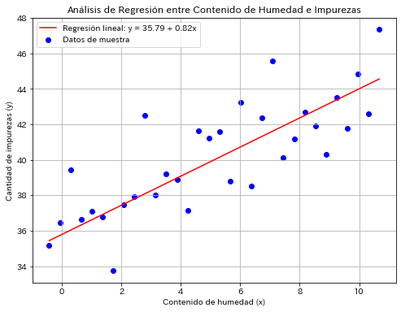

```python
# サンプルデータの生成
x_values = np.linspace(x_bar - 3*np.sqrt(Sxx/n), x_bar + 3*np.sqrt(Sxx/n), n)
y_values = b0 + b1 * x_values + np.random.normal(scale=np.sqrt(Syy/(n-2)), size=n)

# 散布図の描画
x = x_values
y = y_values

print("\nサンプルデータから求めた統計量:")
# F検定
f_val, p_val = f_oneway(x, y)

#相関係数の算出
correlation = np.corrcoef(x,y)[0,1]
print(f"相関係数：{correlation:.3f}")

# データフレームの作成
df = pd.DataFrame({'x': x, 'y': y})

# 回帰分析の実行
model = smf.ols('y ~ x', data=df).fit()

# 回帰直線の係数を取得
b00 = model.params['Intercept']
b11 = model.params['x']

print(f"回帰直線: y = {b00:.2f} + {b11:.2f}x")

# プロット
plt.figure(figsize=(8, 6))

# 回帰直線のプロット
plt.plot(x_values, b0 + b1 * x_values, color='red', label=f'Regresión lineal: y = {b0:.2f} + {b1:.2f}x')

# サンプルデータのプロット
plt.scatter(x_values, y_values, color='blue', label='Datos de muestra')

plt.xlabel('Contenido de humedad (x)')
plt.ylabel('Cantidad de impurezas (y)')
plt.title('Análisis de Regresión entre Contenido de Humedad e Impurezas')
plt.legend()
plt.grid(True)
plt.show()
```

## 15.5

15.4 のデータを用いて、水分含有量 (x) と不純物 (y) の間に直線関係が存在するかどうか、分散分析表を作成して検討せよ。

Utilizando los datos de 15.4, elabora una tabla de análisis de varianza para examinar si existe una relación lineal entre el contenido de humedad (x) y las impurezas (y)

```python
# Estadístico de prueba dado
n = 32
x_bar = 5.125
Sxx = 109.50
Syy = 97.00
Sxy = 90.00

# Cálculo del coeficiente re regresión
b1 = Sxy / Sxx
b0 = y_bar - b1 * x_bar

# Suma de cuadrados total (SST)
SST = Syy

# Suma de cuadrados de la regresión (SSR)
SSR = b1 * Sxy

# Suma de cuadrados de los residuos (SSE)
SSE = SST - SSR

# Grados de libertad
df_total = n - 1
df_regression = 1
df_residual = n - 2

# Cuadrado medio
MSR = SSR / df_regression
MSE = SSE / df_residual

# Value F
F_value = MSR / MSE



# Elaboración de la tabla de análisis de varianza (ANOVA)
anova_table = pd.DataFrame({
    'Fuente de variación': ['Regresión', 'Residuo', 'Total'],
    'Suma de cuadrados (SS)': [SSR, SSE, SST],
    'Grados de libertad (df)': [df_regression, df_residual, df_total],
    'Cuadrado medio (MS)': [MSR, MSE, np.nan],
    'Valor F': [F_value, np.nan, np.nan]
})
anova_table = anova_table.round(3)
anova_table = anova_table.set_index('Fuente de variación')

# 結果の表示
print(f"Ecuación de regresión: y = {b0:.2f} + {b1:.2f}x")
print("\nTabla de análisis de varianza (ANOVA):")
anova_table
```

```
Ecuación de regresión: y = 35.79 + 0.82x

Tabla de análisis de varianza (ANOVA):
```

| Fuente de variación | Suma de cuadrados (SS) | Grados de libertad (df) | Cuadrado medio (MS) | Valor F |
| --- | --- | --- | --- | --- |
| Regresión | 73.973 | 1 | 73.973 | 96.371 |
| Residuo | 23.027 | 30 | 0.768 | NaN |
| Total | 97.000 | 31 | NaN | NaN |

Como resultado del análisis de varianza,

$ F_0 = 96.3 > F(1,30:0.05) = 4.17 $

con un nivel de significancia del 5%, la variación debido a la regresión es significativa. Es decir, existe una relación lineal entre el contenido de humedad (x) y la cantidad de impurezas (y).

```python
from scipy.stats import f

# Grados de libertad
df1 = df_regression
df2 = df_residual
alpha = alpha

f_critical = f.ppf(1 - alpha, df1, df2)

print(f"F0 = {F_value:.4f}")
print(f"F({df1}, {df2}; {alpha}) = {f_critical:.4f}")

# Cálculo del coeficiente de determinación
contribution_ratio = SSR / SST * 100

print(f"\nCoeficiente de determinación: {contribution_ratio:.2f}%")
```

```
F0 = 96.3712
F(1, 30; 0.05) = 4.1709

Coeficiente de determinación: 76.26%
```

```python
notebook_name = 'QCKentei2-8.ipynb'
notebook_name_html = notebook_name.replace(".ipynb",".html")

!jupyter nbconvert --to html {notebook_name}
```

```
[NbConvertApp] Converting notebook QCKentei2-8.ipynb to html
[NbConvertApp] Writing 882332 bytes to QCKentei2-8.html
```